# 机器学习与因果推断 - 第二讲：概率与回归基础

从预测到因果：完整讲义

作者

单位

陈志远

中国人民大学商学院

发布于

2026年3月9日

# 1 上节课回顾

## 1.1 核心概念

在第一讲中，我们建立了因果推断的基础认知：

1. **相关性 ≠ 因果性**：混淆变量会导致虚假相关
2. **潜在结果框架**：每个个体有两种潜在状态 $Y_i(1)$ 和 $Y_i(0)$
3. **选择偏误**：$E[Y_0|D=1] \neq E[Y_0|D=0]$ 使得简单比较失效

## 1.2 本节课目标

本讲将建立概率统计与回归分析的数学基础：

1. 复习概率与统计基础
2. 理解回归的本质——条件期望
3. 区分”预测”与”因果”两种目标
4. 为后续因果推断方法打下数学基础

# 2 概率论基础

## 2.1 为什么要学习概率？

### 2.1.1 因果推断的不确定性

因果推断面临一个根本问题：**我们无法同时观察到 $Y_i(1)$ 和 $Y_i(0)$**。这意味着：

- 只能基于样本推断总体因果效应
- 需要量化估计的不确定性
- 概率论提供了这种量化工具

**例子**：新药试验中，100人服药、100人服安慰剂，观察到的差异可能是”真实效果”或”随机波动”。

### 2.1.2 概率论在因果推断中的作用

| 应用场景 | 概率工具 |
| --- | --- |
| 估计因果效应 | 期望、方差、大数定律 |
| 量化不确定性 | 置信区间、假设检验 |
| 处理选择机制 | 条件概率、贝叶斯定理 |
| 构建预测模型 | 条件期望、回归分析 |

## 2.2 随机变量与分布

### 2.2.1 随机变量的定义

**随机变量 (Random Variable)** 是将随机结果映射为数值的函数。分为两类：

- **离散型**：取值可数（如二项分布、泊松分布）
- **连续型**：取值不可数（如正态分布、均匀分布）

### 2.2.2 正态分布（高斯分布）

正态分布是最重要的概率分布：

$$X \sim N(\mu, \sigma^2)$$

概率密度函数：
$$f(x) = \frac{1}{\sqrt{2\pi\sigma^2}} \exp\left(-\frac{(x-\mu)^2}{2\sigma^2}\right)$$

**性质**：

- 均值：$E[X] = \mu$
- 方差：$Var(X) = \sigma^2$
- 68-95-99.7 规则
- 中心极限定理的基础

## 2.3 模拟实验：Python实现

让我们用Python模拟不同的概率分布，观察其特性。

### 2.3.1 代码实现

**点击查看完整代码**

```python
import numpy as np
import matplotlib.pyplot as plt
from scipy import stats

# 设置随机种子
np.random.seed(42)
n = 10000

# 生成不同分布的样本
normal = np.random.normal(0, 1, n)
binomial = np.random.binomial(10, 0.3, n)
poisson = np.random.poisson(3, n)
uniform = np.random.uniform(0, 1, n)

# 计算统计量
print("样本统计量：")
print(f"正态分布 N(0,1) - 均值: {normal.mean():.3f}, 标准差: {normal.std():.3f}")
print(f"二项分布 Bin(10,0.3) - 均值: {binomial.mean():.3f}, 方差: {binomial.var():.3f}")
print(f"泊松分布 Pois(3) - 均值: {poisson.mean():.3f}, 方差: {poisson.var():.3f}")
print(f"均匀分布 U(0,1) - 均值: {uniform.mean():.3f}, 方差: {uniform.var():.3f}")
```

```
样本统计量：
正态分布 N(0,1) - 均值: -0.002, 标准差: 1.003
二项分布 Bin(10,0.3) - 均值: 3.038, 方差: 2.141
泊松分布 Pois(3) - 均值: 2.990, 方差: 2.951
均匀分布 U(0,1) - 均值: 0.501, 方差: 0.082
```

### 2.3.2 可视化结果

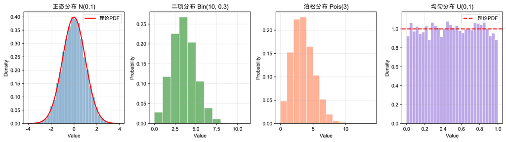

常见概率分布的可视化

```python
fig, axes = plt.subplots(1, 4, figsize=(14, 4))

# 正态分布
x = np.linspace(-4, 4, 1000)
axes[0].hist(normal, bins=30, density=True, alpha=0.6, color='steelblue', edgecolor='white')
axes[0].plot(x, stats.norm.pdf(x, 0, 1), 'r-', lw=2, label='理论PDF')
axes[0].set_title('正态分布 N(0,1)', fontweight='bold')
axes[0].set_xlabel('Value')
axes[0].set_ylabel('Density')
axes[0].legend()
axes[0].grid(alpha=0.3)

# 二项分布
axes[1].hist(binomial, bins=range(12), density=True, alpha=0.6, color='forestgreen', edgecolor='white')
axes[1].set_title('二项分布 Bin(10, 0.3)', fontweight='bold')
axes[1].set_xlabel('Value')
axes[1].set_ylabel('Probability')
axes[1].grid(alpha=0.3)

# 泊松分布
axes[2].hist(poisson, bins=range(15), density=True, alpha=0.6, color='coral', edgecolor='white')
axes[2].set_title('泊松分布 Pois(3)', fontweight='bold')
axes[2].set_xlabel('Value')
axes[2].set_ylabel('Probability')
axes[2].grid(alpha=0.3)

# 均匀分布
axes[3].hist(uniform, bins=30, density=True, alpha=0.6, color='mediumpurple', edgecolor='white')
axes[3].axhline(y=1, color='red', linestyle='--', linewidth=2, label='理论PDF')
axes[3].set_title('均匀分布 U(0,1)', fontweight='bold')
axes[3].set_xlabel('Value')
axes[3].set_ylabel('Density')
axes[3].legend()
axes[3].grid(alpha=0.3)

plt.tight_layout()
plt.show()
```

### 2.3.3 关键发现

- **样本统计量接近理论值**：体现大数定律
- **直方图形状反映分布特性**：正态分布的钟形、二项分布的离散性
- **固定随机种子**确保结果可重复——科学研究的基本要求

## 2.4 期望与方差

### 2.4.1 期望 (Expected Value)

随机变量的”长期平均值”：

- **离散型**：$E[X] = \sum_i x_i \cdot P(X=x_i)$
- **连续型**：$E[X] = \int_{-\infty}^{\infty} x \cdot f(x) dx$

### 2.4.2 方差 (Variance)

衡量随机变量的”离散程度”：

$$Var(X) = E[(X - E[X])^2] = E[X^2] - (E[X])^2$$

### 2.4.3 重要性质

| 性质 | 公式 |
| --- | --- |
| 线性性 | $E[aX + b] = aE[X] + b$ |
| 方差缩放 | $Var(aX + b) = a^2 Var(X)$ |
| 期望可加 | $E[X + Y] = E[X] + E[Y]$ |
| 方差可加（独立） | $Var(X + Y) = Var(X) + Var(Y)$ |

### 2.4.4 常见分布的期望与方差

| 分布 | 概率函数 | 均值 | 方差 |
| --- | --- | --- | --- |
| 正态分布 $N(\mu, \sigma^2)$ | $\frac{1}{\sqrt{2\pi\sigma^2}}e^{-\frac{(x-\mu)^2}{2\sigma^2}}$ | $\mu$ | $\sigma^2$ |
| 二项分布 $Bin(n,p)$ | $\binom{n}{k}p^k(1-p)^{n-k}$ | $np$ | $np(1-p)$ |
| 泊松分布 $Pois(\lambda)$ | $\frac{\lambda^k e^{-\lambda}}{k!}$ | $\lambda$ | $\lambda$ |

## 2.5 大数定律与中心极限定理

### 2.5.1 大数定律 (Law of Large Numbers)

随着样本量增加，样本均值收敛于总体期望：

$$\bar{X}_n = \frac{1}{n}\sum_{i=1}^n X_i \xrightarrow{p} E[X]$$

**直观理解**：抛硬币次数越多，正面比例越接近 50%。

### 2.5.2 中心极限定理 (Central Limit Theorem)

无论总体分布如何，样本均值的分布趋近正态：

$$\sqrt{n}(\bar{X}_n - \mu) \xrightarrow{d} N(0, \sigma^2)$$

**直观理解**：大量独立随机因素叠加，结果趋于正态分布。

### 2.5.3 模拟验证

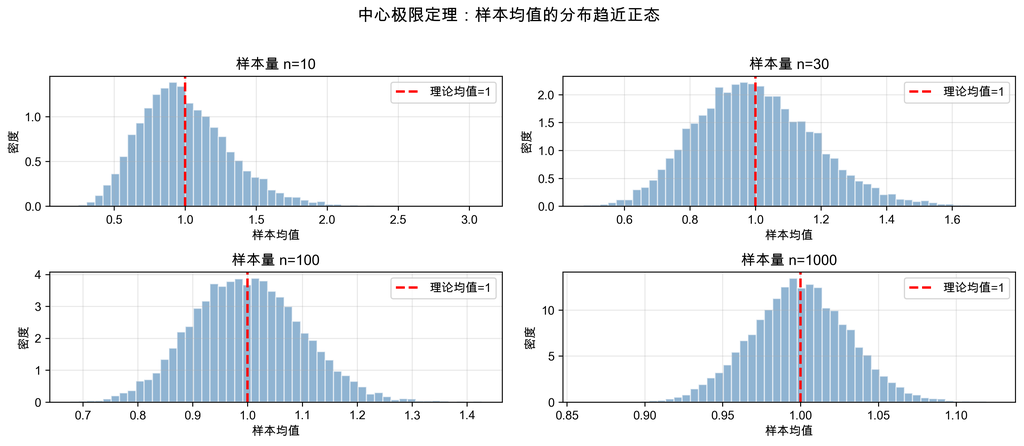

中心极限定理的模拟验证

```python
# 模拟不同样本量下的样本均值分布
sample_sizes = [10, 30, 100, 1000]
n_simulations = 10000

fig, axes = plt.subplots(2, 2, figsize=(12, 5))
axes = axes.flatten()

for idx, n in enumerate(sample_sizes):
    # 从指数分布中抽样（非正态分布）
    sample_means = [np.random.exponential(1, n).mean() for _ in range(n_simulations)]

    axes[idx].hist(sample_means, bins=50, density=True, alpha=0.6, color='steelblue', edgecolor='white')
    axes[idx].axvline(x=1, color='red', linestyle='--', linewidth=2, label='理论均值=1')
    axes[idx].set_title(f'样本量 n={n}', fontweight='bold')
    axes[idx].set_xlabel('样本均值')
    axes[idx].set_ylabel('密度')
    axes[idx].legend()
    axes[idx].grid(alpha=0.3)

plt.suptitle('中心极限定理：样本均值的分布趋近正态', fontsize=14, fontweight='bold', y=1.02)
plt.tight_layout()
plt.show()
```

### 2.5.4 为什么重要？

- **LLN 保证估计的一致性**：样本越大，估计越准确
- **CLT 让我们可以构建置信区间、进行假设检验**
- **这是统计推断的数学基础**

# 3 条件概率与条件期望

## 3.1 条件概率

### 3.1.1 定义

在事件 $B$ 发生的条件下，事件 $A$ 发生的概率：

$$P(A|B) = \frac{P(A \cap B)}{P(B)}$$

### 3.1.2 贝叶斯定理

$$P(A|B) = \frac{P(B|A) \cdot P(A)}{P(B)}$$

### 3.1.3 条件概率与因果推断

在因果推断中，我们经常问：“给定处理状态 $D=1$，结果 $Y$ 的分布是什么？”

但这不等于”处理对 $Y$ 的因果效应”，因为：

- $P(Y|D=1)$ 和 $P(Y|D=0)$ 的比较可能包含选择偏误
- 需要额外的假设才能识别因果效应

## 3.2 条件期望函数 (CEF)

### 3.2.1 定义

在给定 $X=x$ 的条件下，$Y$ 的期望：

$$E[Y|X=x]$$

**条件期望函数 (CEF)**：
$$g(x) = E[Y|X=x]$$

### 3.2.2 关键洞见

- CEF 是 $X$ 的函数，描述了 $Y$ 如何随 $X$ 系统性地变化
- 我们可以将 $Y$ 分解为：$Y = E[Y|X] + \varepsilon$
- 其中 $\varepsilon = Y - E[Y|X]$ 满足 $E[\varepsilon|X] = 0$

### 3.2.3 例子：教育与收入

- $E[\text{收入}|\text{教育}=12]$：高中毕业生的平均收入
- $E[\text{收入}|\text{教育}=16]$：大学毕业生的平均收入
- **注意**：差异是教育的”相关关系”，但未必是”因果效应”

## 3.3 Python：计算条件期望

**条件期望计算代码**

```python
import numpy as np
import pandas as pd
import matplotlib.pyplot as plt

# 设置随机种子
np.random.seed(42)
n = 10000

# 模拟数据：教育年限与收入
education = np.random.choice([12, 14, 16, 18], size=n,
                              p=[0.3, 0.2, 0.35, 0.15])

# 收入 = 基础 + 教育回报 + 能力因素 + 噪声
ability = np.random.normal(0, 1, n)
income = 20000 + education * 3000 + ability * 10000 + np.random.normal(0, 5000, n)

data = pd.DataFrame({'education': education, 'income': income, 'ability': ability})

# 计算条件期望 E[收入|教育]
conditional_means = data.groupby('education')['income'].mean()
conditional_vars = data.groupby('education')['income'].var()

print("条件期望 E[收入|教育]:")
for edu, mean_income in conditional_means.items():
    print(f"  教育{edu}年: 平均收入 = {mean_income:.0f}元")

print("\n条件方差 Var(收入|教育]:")
for edu, var_income in conditional_vars.items():
    print(f"  教育{edu}年: 收入方差 = {var_income:.0f}")
```

```
条件期望 E[收入|教育]:
  教育12年: 平均收入 = 56344元
  教育14年: 平均收入 = 62015元
  教育16年: 平均收入 = 68108元
  教育18年: 平均收入 = 73785元

条件方差 Var(收入|教育]:
  教育12年: 收入方差 = 126324032
  教育14年: 收入方差 = 125614249
  教育16年: 收入方差 = 130641323
  教育18年: 收入方差 = 118973987
```

### 3.3.1 可视化条件期望

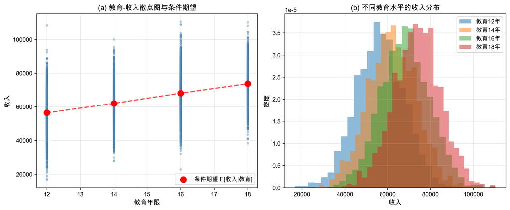

条件期望函数的可视化

```python
fig, axes = plt.subplots(1, 2, figsize=(12, 5))

# 左图：散点图 + 条件均值
axes[0].scatter(data['education'], data['income'], alpha=0.3, s=10, color='steelblue')
axes[0].scatter(conditional_means.index, conditional_means.values,
               color='red', s=100, zorder=5, label='条件期望 E[收入|教育]')
axes[0].plot(conditional_means.index, conditional_means.values,
            'r--', linewidth=2, alpha=0.7)
axes[0].set_xlabel('教育年限', fontsize=11)
axes[0].set_ylabel('收入', fontsize=11)
axes[0].set_title('(a) 教育-收入散点图与条件期望', fontweight='bold')
axes[0].legend()
axes[0].grid(alpha=0.3)

# 右图：不同教育水平的收入分布
for edu in [12, 14, 16, 18]:
    subset = data[data['education'] == edu]['income']
    axes[1].hist(subset, bins=30, alpha=0.5, label=f'教育{edu}年', density=True)
axes[1].set_xlabel('收入', fontsize=11)
axes[1].set_ylabel('密度', fontsize=11)
axes[1].set_title('(b) 不同教育水平的收入分布', fontweight='bold')
axes[1].legend()
axes[1].grid(alpha=0.3)

plt.tight_layout()
plt.show()
```

## 3.4 迭代期望定律 (Law of Iterated Expectations)

### 3.4.1 定理

$$E[Y] = E[E[Y|X]]$$

“期望的期望等于期望”

### 3.4.2 直观理解

总体的平均收入 = 各教育组的平均收入的加权平均

$$E[\text{收入}] = \sum_{e} E[\text{收入}|\text{教育}=e] \cdot P(\text{教育}=e)$$

### 3.4.3 验证

```python
# 验证迭代期望定律
overall_mean = data['income'].mean()
education_probs = data['education'].value_counts(normalize=True).sort_index()
weighted_mean = sum(conditional_means[edu] * education_probs[edu] for edu in conditional_means.index)

print(f"总体平均收入: {overall_mean:.2f}")
print(f"加权条件期望: {weighted_mean:.2f}")
print(f"差异: {abs(overall_mean - weighted_mean):.6f} (应接近0)")
```

```
总体平均收入: 64106.00
加权条件期望: 64106.00
差异: 0.000000 (应接近0)
```

### 3.4.4 重要性

- 允许我们”分而治之”：先分组计算，再加权平均
- 是许多计量经济学推导的基础
- 理解缺失数据、选择模型的关键

# 4 回归分析基础

## 4.1 什么是回归？

### 4.1.1 回归的两种视角

1. **预测视角**：找到最好的函数 $f(X)$ 来预测 $Y$
2. **因果视角**：估计 $X$ 对 $Y$ 的因果效应

**这两种目标需要不同的假设和方法！**

### 4.1.2 线性回归模型

$$Y = \beta_0 + \beta_1 X + \varepsilon$$

其中：

- $\beta_0$：截距（当 $X=0$ 时 $Y$ 的期望值）
- $\beta_1$：斜率（$X$ 增加 1 单位，$Y$ 的期望变化）
- $\varepsilon$：误差项

### 4.1.3 关键问题

OLS 估计的 $\hat{\beta}_1$ 在什么条件下可以解释为因果效应？

## 4.2 普通最小二乘法 (OLS)

### 4.2.1 OLS 的目标

最小化残差平方和：

$$\min_{\beta_0, \beta_1} \sum_{i=1}^n (Y_i - \beta_0 - \beta_1 X_i)^2$$

### 4.2.2 OLS 估计量

$$\hat{\beta}_1 = \frac{\sum_{i=1}^n (X_i - \bar{X})(Y_i - \bar{Y})}{\sum_{i=1}^n (X_i - \bar{X})^2} = \frac{Cov(X, Y)}{Var(X)}$$

$$\hat{\beta}_0 = \bar{Y} - \hat{\beta}_1 \bar{X}$$

### 4.2.3 OLS 与 CEF 的关系

- OLS 提供了对 CEF 的最佳线性近似
- 如果真实的 CEF 是线性的，OLS 估计的是真实的条件期望
- 即使 CEF 非线性，OLS 仍是最优线性预测

## 4.3 Python：OLS 回归

**OLS回归完整代码**

```python
import numpy as np
import pandas as pd
import statsmodels.api as sm
import matplotlib.pyplot as plt

# 设置随机种子
np.random.seed(42)
n = 1000

# 生成数据
X = np.random.normal(10, 2, n)  # 解释变量
epsilon = np.random.normal(0, 5, n)  # 误差项
Y = 2 + 3 * X + epsilon  # 真实模型：Y = 2 + 3X + ε

# 添加常数项（截距）
X_const = sm.add_constant(X)

# 拟合 OLS 模型
model = sm.OLS(Y, X_const)
results = model.fit()

# 输出结果
print(results.summary())

# 提取关键统计量
print(f"\n估计系数:")
print(f"  截距 (β₀): {results.params[0]:.4f} (真实值: 2)")
print(f"  斜率 (β₁): {results.params[1]:.4f} (真实值: 3)")
print(f"\n标准误:")
print(f"  β₀: {results.bse[0]:.4f}")
print(f"  β₁: {results.bse[1]:.4f}")
print(f"\nR²: {results.rsquared:.4f}")
print(f"调整R²: {results.rsquared_adj:.4f}")
```

```
                            OLS Regression Results
==============================================================================
Dep. Variable:                      y   R-squared:                       0.565
Model:                            OLS   Adj. R-squared:                  0.564
Method:                 Least Squares   F-statistic:                     1294.
Date:                Sun, 12 Apr 2026   Prob (F-statistic):          2.32e-182
Time:                        20:28:57   Log-Likelihood:                -3024.5
No. Observations:                1000   AIC:                             6053.
Df Residuals:                     998   BIC:                             6063.
Df Model:                           1
Covariance Type:            nonrobust
==============================================================================
                 coef    std err          t      P>|t|      [0.025      0.975]
------------------------------------------------------------------------------
const          3.3870      0.824      4.111      0.000       1.770       5.004
x1             2.8971      0.081     35.969      0.000       2.739       3.055
==============================================================================
Omnibus:                        0.840   Durbin-Watson:                   2.029
Prob(Omnibus):                  0.657   Jarque-Bera (JB):                0.716
Skew:                          -0.049   Prob(JB):                        0.699
Kurtosis:                       3.087   Cond. No.                         53.9
==============================================================================

Notes:
[1] Standard Errors assume that the covariance matrix of the errors is correctly specified.

估计系数:
  截距 (β₀): 3.3870 (真实值: 2)
  斜率 (β₁): 2.8971 (真实值: 3)

标准误:
  β₀: 0.8238
  β₁: 0.0805

R²: 0.5645
调整R²: 0.5641
```

### 4.3.1 回归结果可视化

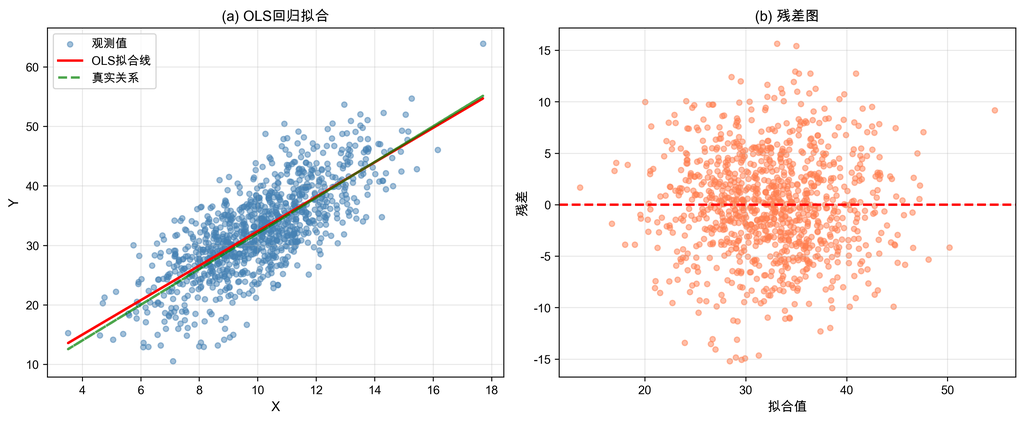

OLS回归结果可视化

```python
fig, axes = plt.subplots(1, 2, figsize=(12, 5))

# 左图：散点图 + 回归线
axes[0].scatter(X, Y, alpha=0.5, s=20, color='steelblue', label='观测值')
axes[0].plot(X, results.predict(X_const), 'r-', linewidth=2, label='OLS拟合线')
axes[0].plot(X, 2 + 3*X, 'g--', linewidth=2, alpha=0.7, label='真实关系')
axes[0].set_xlabel('X', fontsize=11)
axes[0].set_ylabel('Y', fontsize=11)
axes[0].set_title('(a) OLS回归拟合', fontweight='bold')
axes[0].legend()
axes[0].grid(alpha=0.3)

# 右图：残差图
residuals = results.resid
fitted = results.fittedvalues
axes[1].scatter(fitted, residuals, alpha=0.5, s=20, color='coral')
axes[1].axhline(y=0, color='red', linestyle='--', linewidth=2)
axes[1].set_xlabel('拟合值', fontsize=11)
axes[1].set_ylabel('残差', fontsize=11)
axes[1].set_title('(b) 残差图', fontweight='bold')
axes[1].grid(alpha=0.3)

plt.tight_layout()
plt.show()
```

## 4.4 多元回归

### 4.4.1 多元线性回归模型

当有多个解释变量时：

$$Y = \beta_0 + \beta_1 X_1 + \beta_2 X_2 + \cdots + \beta_k X_k + \varepsilon$$

### 4.4.2 矩阵形式

$$\mathbf{Y} = \mathbf{X}\boldsymbol{\beta} + \boldsymbol{\varepsilon}$$

**OLS 估计量**：
$$\hat{\boldsymbol{\beta}} = (\mathbf{X}'\mathbf{X})^{-1}\mathbf{X}'\mathbf{Y}$$

### 4.4.3 偏回归系数

- $\beta_j$ 表示：在保持其他变量不变的情况下，$X_j$ 增加 1 单位，$Y$ 的期望变化
- 这是”控制其他因素”的数学实现
- **但要注意**：控制变量只能控制观测到的因素！

## 4.5 遗漏变量偏误演示

### 4.5.1 模拟数据生成

**遗漏变量偏误模拟代码**

```python
import numpy as np
import pandas as pd
import statsmodels.api as sm

# 设置随机种子
np.random.seed(42)
n = 1000

# 生成数据
education = np.random.normal(12, 3, n)  # 教育年限
experience = np.random.normal(10, 5, n)  # 工作经验
ability = np.random.normal(0, 1, n)  # 能力（通常不可观测）

# 收入由教育、经验和能力决定
income = 10000 + 2000 * education + 1500 * experience + 10000 * ability + np.random.normal(0, 8000, n)

data = pd.DataFrame({
    'income': income,
    'education': education,
    'experience': experience,
    'ability': ability
})

# 模型1：简单回归（遗漏能力和经验）
X1 = sm.add_constant(data['education'])
model1 = sm.OLS(data['income'], X1).fit()

# 模型2：多元回归（控制经验，但仍遗漏能力）
X2 = sm.add_constant(data[['education', 'experience']])
model2 = sm.OLS(data['income'], X2).fit()

# 模型3：包含能力（现实中通常不可观测）
X3 = sm.add_constant(data[['education', 'experience', 'ability']])
model3 = sm.OLS(data['income'], X3).fit()

print("=" * 70)
print("遗漏变量偏误演示")
print("=" * 70)
print(f"\n模型1（仅教育）教育系数: {model1.params['education']:.2f}")
print(f"模型2（教育+经验）教育系数: {model2.params['education']:.2f}")
print(f"模型3（教育+经验+能力）教育系数: {model3.params['education']:.2f}")
print(f"\n真实参数（数据生成时）: 2000.00")
print("=" * 70)
```

```
======================================================================
遗漏变量偏误演示
======================================================================

模型1（仅教育）教育系数: 1933.94
模型2（教育+经验）教育系数: 2029.17
模型3（教育+经验+能力）教育系数: 1955.19

真实参数（数据生成时）: 2000.00
======================================================================
```

### 4.5.2 结果解读

[output not shown]

### 4.5.3 关键启示

- **遗漏变量偏误方向**：取决于遗漏变量与 $X$ 和 $Y$ 的相关性
- **现实中**：能力等关键变量往往不可观测
- **解决方案**：需要工具变量、固定效应、随机实验等方法

# 5 预测 vs 因果

## 5.1 预测的目标

### 5.1.1 预测 (Prediction)

目标：最小化预测误差，准确预测 $Y$

关心的是：$\hat{Y}$ 与 $Y$ 有多接近？

### 5.1.2 预测中的”黑箱”是可以接受的

- **机器学习模型**（随机森林、神经网络）中的具体机制可以是黑箱
- 只要预测准确，我们**不关心内部机制**
- **交叉验证**是评估预测性能的金标准

### 5.1.3 预测问题的例子

- 预测明天的股价
- 预测客户是否会流失
- 预测贷款违约概率
- 推荐系统（预测用户喜欢的商品）

## 5.2 因果推断的目标

### 5.2.1 因果推断 (Causal Inference)

目标：估计 $X$ 对 $Y$ 的因果效应

关心的是：如果改变 $X$，$Y$ 会如何变化？

### 5.2.2 因果推断需要”白箱”

- 必须理解为什么估计量有效
- 需要明确的识别假设
- **统计相关性 ≠ 因果效应**

### 5.2.3 因果问题的例子

- 广告投入是否增加销量？
- 教育是否提高收入？
- 新药是否改善健康？
- 政策是否减少贫困？

## 5.3 预测与因果的对比

| 维度 | 预测 | 因果推断 |
| --- | --- | --- |
| **核心问题** | $Y$ 是什么？ | 如果改变 $X$，$Y$ 会如何？ |
| **目标** | 最小化预测误差 | 无偏、一致地估计因果效应 |
| **过拟合** | 需要避免 | 不是主要问题 |
| **可解释性** | 可以黑箱 | 必须可解释 |
| **假设** | 数据分布稳定 | 需要因果识别假设 |
| **方法** | ML、交叉验证 | 实验、准实验、IV、DID 等 |
| **外推** | 需要谨慎 | 需要更强的假设 |

### 5.3.1 常见错误

用预测的方法做因果推断，或用因果的方法做预测，都会导致错误结论！

## 5.4 为什么回归系数不等于因果效应？

### 5.4.1 例子：教育与收入

回归结果：每多受一年教育，收入平均增加 8%

但这*不一定*是教育的因果效应，因为：

1. **能力偏误**：能力强的人既爱学习又能赚钱
2. **家庭背景**：富裕家庭的孩子教育更多、收入也更高
3. **信号效应**：文凭可能只是能力的信号
4. **选择效应**：选择继续上学的人本来就有更高的收入潜力

### 5.4.2 遗漏变量偏误公式

如果遗漏的变量 $Z$ 既影响 $X$ 又影响 $Y$，则：

$$\text{偏误方向} = \text{Corr}(X, Z) \times \text{Corr}(Z, Y)$$

只有当遗漏变量与 $X$ 无关时，才不会有偏误。

## 5.5 火鸡悖论

### 5.5.1 罗素的火鸡悖论 (Russell’s Turkey)

有一只火鸡，它发现每天上午9点，主人都会准时来喂食。经过100天的观察，火鸡得出结论：“主人会在每天上午9点给我喂食。” 火鸡用这个”模型”预测第101天、第102天…都会如此。预测一直很准确，火鸡对自己的”机器学习模型”充满信心。直到感恩节那天，上午9点，主人来了——但这次带来的是一把刀。

### 5.5.2 问题出在哪里？

- **预测视角**：过去100天的数据支持”9点有食物”的预测
- **因果视角**：主人喂食的目的是养肥火鸡过节，而非关爱

> “机器学习可以完美预测过去，但唯有因果理解才能预见未来。”

### 5.5.3 对研究的启示

- 历史数据中的相关性可能在某个”感恩节”突然断裂
- 只有理解背后的因果机制，才能判断何时可以**外推**
- 这是**因果推断优于纯预测方法的关键所在**

# 6 从回归到因果推断

## 6.1 回归的因果解释需要什么？

### 6.1.1 关键假设：条件独立假设 (CIA)

给定控制变量 $X$，处理分配 $D$ 与潜在结果独立：

$$(Y_0, Y_1) \perp D | X$$

或更弱的形式：$E[Y_0|D=1, X] = E[Y_0|D=0, X]$

### 6.1.2 直观理解

- 在相同的 $X$ 水平下，处理组和控制组是可比较的
- 控制 $X$ 后，处理分配”就像是随机的”
- 这时，回归系数可以解释为因果效应

### 6.1.3 问题

- 我们永远不知道是否控制了所有混杂因素
- 需要理论指导哪些变量应该控制
- 需要排除”坏控制变量”（中介变量、碰撞变量）

# 7 本讲总结

## 7.1 核心要点回顾

### 7.1.1 概率与统计基础

- 随机变量、期望、方差
- 条件概率与条件期望
- 大数定律与中心极限定理
- 迭代期望定律

### 7.1.2 回归分析

- OLS 估计与性质
- 多元回归与偏效应
- 预测 vs 因果的区别
- 遗漏变量偏误问题

### 7.1.3 关键公式汇总

| 概念 | 公式 |
| --- | --- |
| 期望 | $E[X] = \sum_i x_i P(X=x_i)$ |
| 方差 | $Var(X) = E[X^2] - (E[X])^2$ |
| 条件期望 | $E[Y\|X=x]$ |
| 迭代期望 | $E[Y] = E[E[Y\|X]]$ |
| OLS估计 | $\hat{\beta} = (X'X)^{-1}X'Y$ |

## 7.2 下节课预告

**第三讲：有向无环图 (DAGs)——因果推断的可视化语言**

- 如何用图形表示因果关系
- 识别混杂因素、中介变量、工具变量
- d-分离与后门准则
- 为后续方法打下图形化基础

## 7.3 练习与作业

### 7.3.1 理论题

1. 证明 $Var(X) = E[X^2] - (E[X])^2$
2. 解释迭代期望定律的直观含义
3. 推导 OLS 估计量的无偏性条件
4. 分析以下情境中的遗漏变量偏误方向：
   - 估计教育对收入的影响，遗漏能力变量
   - 估计广告对销量的影响，遗漏季节因素

### 7.3.2 编程题（Python 或 R）

1. 模拟数据验证中心极限定理
2. 用 OLS 复现课堂示例，展示遗漏变量偏误
3. 绘制条件期望函数的可视化

## 7.4 推荐阅读

- Cunningham (2021): “Causal Inference: The Mixtape” - Chapter 2
- Angrist & Pischke: “Mostly Harmless Econometrics” - Chapter 1-2
- Huntington-Klein: “The Effect” - Chapter 1

**联系方式**

- 邮箱：chenzhiyuan@rmbs.ruc.edu.cn
- Office Hours：周四 14:00-15:00

*本讲义基于 Scott Cunningham《Causal Inference: The Mixtape》、Angrist & Pischke《Mostly Harmless Econometrics》整理而成。*